# dbfinal

```r
setwd("D:/Computer/Documents/Grad School/Spring22/Databases and Datamining/Final Project")
```

#loading the dataset

```r
diabetes.data <-read.csv("PimaIndiansDiabetes.csv")
diabetes.data <- data.frame(diabetes.data)

#View(diabetes.data)
diabetes.data$Outcome <- as.factor(diabetes.data$Outcome)
```

#Question1 #Q1:Which variables are numeric and which are categorical? Explain why.(10pts)

#answer- #Pregnancies, Glucose, BloodPressure, SkinThickness, Insulin, BMI, DiabetesPedigreeFunction and Age are all numeric variables given that these values come from numerical measurements of a patient. They are quantitative in nature. Also these variables have an almost infinite number of possibilities you can get for each one of them which makes them more of numeric variables.

#Outcome is the target variable and its use is much different from the other variables. It is a categorical variable since whether a person has diabetes or not is assigned into two groups or categories- ie. 1~ yes the patient does have diabetes or 0~ no the patient doesnt have diabetes. This is qualitative in nature.

#Q2: Use appropriate graphs to predict which of the variables (on their own) are most helpful in predicting the outcome? (20pts) #For each variable draw an appropriate graph (boxplot for numerical values and barplot for categorical values). Explain your answer.

#answer-Given that all the variables are numerical asides from the outcome, I made a boxplot for each one below, displaying their relationship with the outcome. After looking at each, the Glucose would be the most helpful and accurate variable for predication given that there is less overlap between the median outomes and there are also less outliers that reside in the data. BMI,number of pregnanacies and age are also 2nd, 3rd and 4th best predictors of whether a patient will have diabtes. The less effective/bad predictors turns out to be Bloodpressure, skinthickness, insulin and DiabetesPedigreeFunction since would have higher rates of false predictions given that there is high overlaps in the medians and there are lots of outliers which would skew the data.

```r
library(dplyr)
```

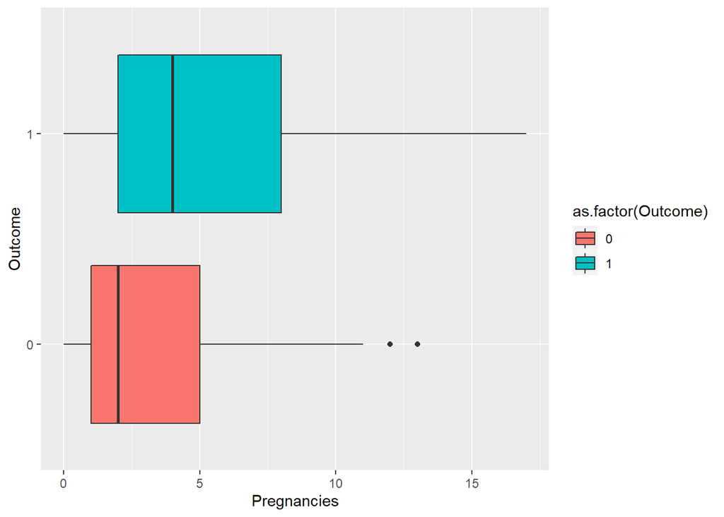

```r
library(ggplot2)
#box plot for Pregnancies
ggplot(data = diabetes.data) +
  geom_boxplot(mapping = aes(x = Pregnancies,y = Outcome, fill=as.factor(Outcome)))
```

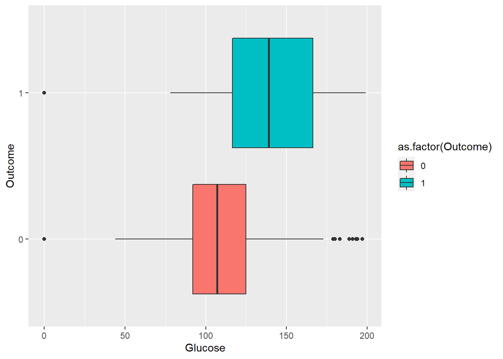

```r
#box plot for Glucose

ggplot(data = diabetes.data) +
  geom_boxplot(mapping = aes(x = Glucose,y = Outcome, fill=as.factor(Outcome)))
```

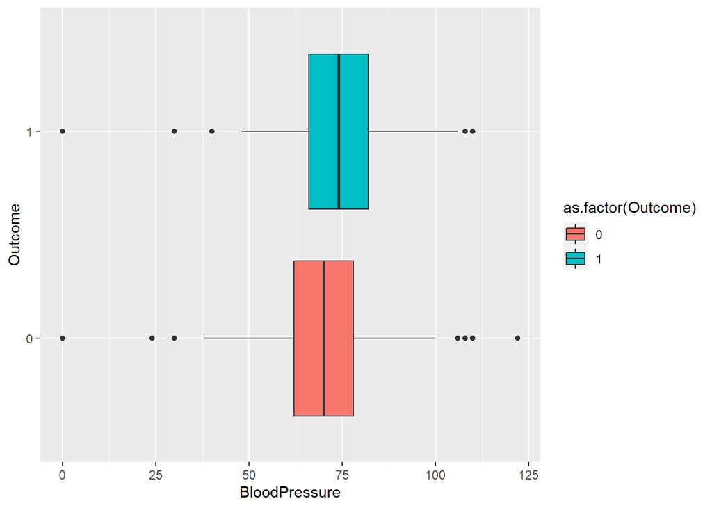

```r
#box plot for Bloodpressure
ggplot(data = diabetes.data) +
  geom_boxplot(mapping = aes(x = BloodPressure,y = Outcome, fill=as.factor(Outcome)))
```

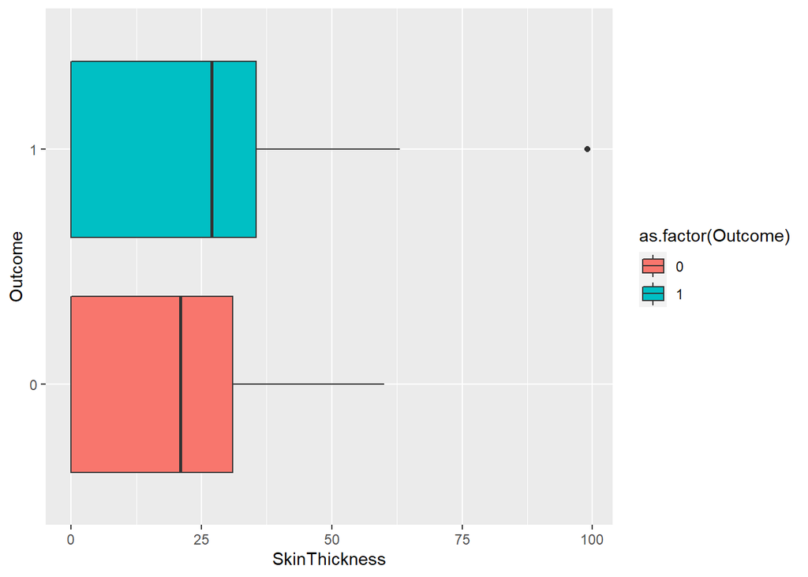

```r
#box plot for Skinthickness
ggplot(data = diabetes.data) +
  geom_boxplot(mapping = aes(x = SkinThickness,y = Outcome, fill=as.factor(Outcome)))
```

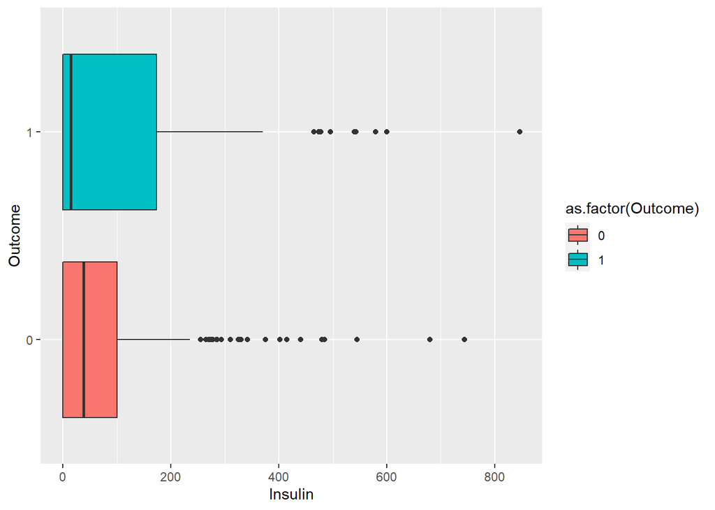

```r
#box plot for Insulin
ggplot(data = diabetes.data) +
  geom_boxplot(mapping = aes(x = Insulin,y = Outcome, fill=as.factor(Outcome)))
```

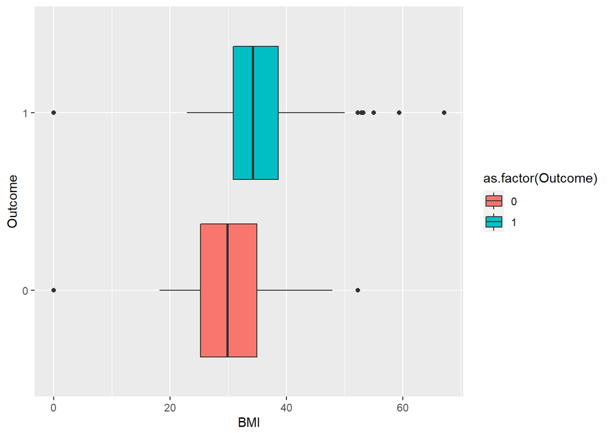

```r
#box plot for BMI
ggplot(data = diabetes.data) +
  geom_boxplot(mapping = aes(x = BMI,y = Outcome, fill=as.factor(Outcome)))
```

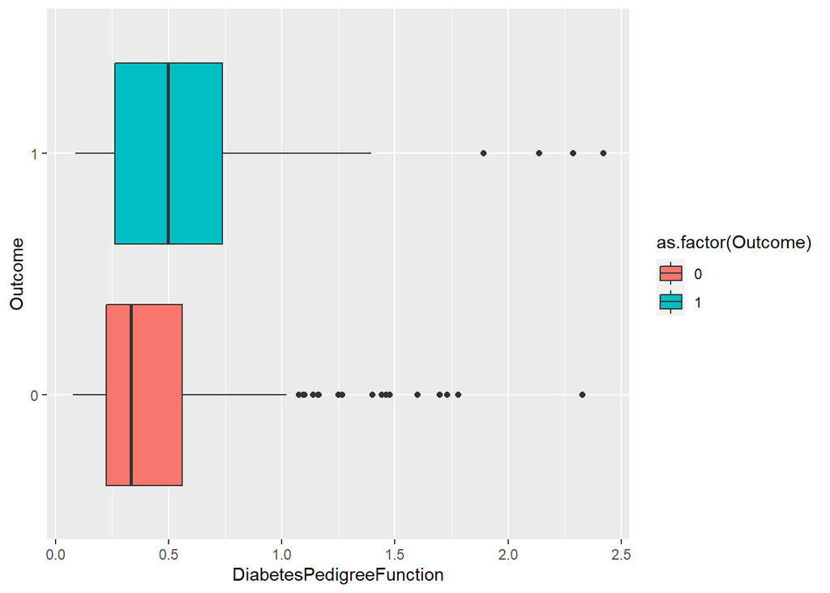

```r
#box plot for DiabetesPedigreeFunction
ggplot(data = diabetes.data) +
  geom_boxplot(mapping = aes(x = DiabetesPedigreeFunction,y = Outcome, fill=as.factor(Outcome)))
```